# House Sales Price prediction with machine learning

Parviz Hajizada

# Introduction

For those who lived through 2007-2008 may not forget the Financial Crisis, which is mentioned as one of most devastating financial crisis after the Great Depression in 1930s.

The crisis started from subprime mortage market in the United States and then quickly affected the banking system worldwide. One of the most basic problem that contributes to the crisis is overestimation or underestimation of house prices.

Before the crisis, machine learning was not widely used due to the cost of technology. Perhaps, if machine learning was used back then, consumer might have clear insight before signing the mortage contract. In this paper, I am building few models to predict house prices in King County - Washington between May 2014 and May 2015.

Data set can be found from the following [link](https://www.kaggle.com/harlfoxem/housesalesprediction).

### Load necessary packages

```r
library(readr)
library(dplyr)
library(tibble)
library(corrplot)
library(ggplot2)
library(AER)
library(lmtest)
library(nnet)
library(MASS)
library(caret)
library(verification)
library(e1071)
library(janitor)
library(class)
library(kernlab)
library(verification)
library(tidyverse)
library(gmodels)
library(vcd)
library(lubridate)
library(gridExtra)
library(devtools)
library(maps)
library(mapdata)
library(ggmap)
```

### Import data

```r
house <- read_csv("kc_house_data.csv")
dim(house)
```

```
## [1] 21613    21
```

# Exploratory Data Analysis

### Descriptive statistics

```r
any(is.na(house))
```

```
## [1] FALSE
```

```r
summary(house)
```

```
##       id                 date                         price
##  Length:21613       Min.   :2014-05-02 00:00:00   Min.   :  75000
##  Class :character   1st Qu.:2014-07-22 00:00:00   1st Qu.: 321950
##  Mode  :character   Median :2014-10-16 00:00:00   Median : 450000
##                     Mean   :2014-10-29 04:38:01   Mean   : 540088
##                     3rd Qu.:2015-02-17 00:00:00   3rd Qu.: 645000
##                     Max.   :2015-05-27 00:00:00   Max.   :7700000
##     bedrooms        bathrooms      sqft_living       sqft_lot
##  Min.   : 0.000   Min.   :0.000   Min.   :  290   Min.   :    520
##  1st Qu.: 3.000   1st Qu.:1.750   1st Qu.: 1427   1st Qu.:   5040
##  Median : 3.000   Median :2.250   Median : 1910   Median :   7618
##  Mean   : 3.371   Mean   :2.115   Mean   : 2080   Mean   :  15107
##  3rd Qu.: 4.000   3rd Qu.:2.500   3rd Qu.: 2550   3rd Qu.:  10688
##  Max.   :33.000   Max.   :8.000   Max.   :13540   Max.   :1651359
##      floors        waterfront            view          condition
##  Min.   :1.000   Min.   :0.000000   Min.   :0.0000   Min.   :1.000
##  1st Qu.:1.000   1st Qu.:0.000000   1st Qu.:0.0000   1st Qu.:3.000
##  Median :1.500   Median :0.000000   Median :0.0000   Median :3.000
##  Mean   :1.494   Mean   :0.007542   Mean   :0.2343   Mean   :3.409
##  3rd Qu.:2.000   3rd Qu.:0.000000   3rd Qu.:0.0000   3rd Qu.:4.000
##  Max.   :3.500   Max.   :1.000000   Max.   :4.0000   Max.   :5.000
##      grade          sqft_above   sqft_basement       yr_built
##  Min.   : 1.000   Min.   : 290   Min.   :   0.0   Min.   :1900
##  1st Qu.: 7.000   1st Qu.:1190   1st Qu.:   0.0   1st Qu.:1951
##  Median : 7.000   Median :1560   Median :   0.0   Median :1975
##  Mean   : 7.657   Mean   :1788   Mean   : 291.5   Mean   :1971
##  3rd Qu.: 8.000   3rd Qu.:2210   3rd Qu.: 560.0   3rd Qu.:1997
##  Max.   :13.000   Max.   :9410   Max.   :4820.0   Max.   :2015
##   yr_renovated       zipcode           lat             long
##  Min.   :   0.0   Min.   :98001   Min.   :47.16   Min.   :-122.5
##  1st Qu.:   0.0   1st Qu.:98033   1st Qu.:47.47   1st Qu.:-122.3
##  Median :   0.0   Median :98065   Median :47.57   Median :-122.2
##  Mean   :  84.4   Mean   :98078   Mean   :47.56   Mean   :-122.2
##  3rd Qu.:   0.0   3rd Qu.:98118   3rd Qu.:47.68   3rd Qu.:-122.1
##  Max.   :2015.0   Max.   :98199   Max.   :47.78   Max.   :-121.3
##  sqft_living15    sqft_lot15
##  Min.   : 399   Min.   :   651
##  1st Qu.:1490   1st Qu.:  5100
##  Median :1840   Median :  7620
##  Mean   :1987   Mean   : 12768
##  3rd Qu.:2360   3rd Qu.: 10083
##  Max.   :6210   Max.   :871200
```

```r
sapply(house, class) %>%
  unlist()
```

```
##            id         date1         date2         price      bedrooms
##   "character"     "POSIXct"      "POSIXt"     "numeric"     "numeric"
##     bathrooms   sqft_living      sqft_lot        floors    waterfront
##     "numeric"     "numeric"     "numeric"     "numeric"     "numeric"
##          view     condition         grade    sqft_above sqft_basement
##     "numeric"     "numeric"     "numeric"     "numeric"     "numeric"
##      yr_built  yr_renovated       zipcode           lat          long
##     "numeric"     "numeric"     "numeric"     "numeric"     "numeric"
## sqft_living15    sqft_lot15
##     "numeric"     "numeric"
```

## Feature engineering

```r
table(house$yr_renovated)
```

```
##
##     0  1934  1940  1944  1945  1946  1948  1950  1951  1953  1954  1955
## 20699     1     2     1     3     2     1     2     1     3     1     3
##  1956  1957  1958  1959  1960  1962  1963  1964  1965  1967  1968  1969
##     3     3     5     1     4     2     4     5     5     2     8     4
##  1970  1971  1972  1973  1974  1975  1976  1977  1978  1979  1980  1981
##     9     2     4     5     3     6     3     8     6    10    11     5
##  1982  1983  1984  1985  1986  1987  1988  1989  1990  1991  1992  1993
##    11    18    18    17    17    18    15    22    25    20    17    19
##  1994  1995  1996  1997  1998  1999  2000  2001  2002  2003  2004  2005
##    19    16    15    15    19    17    35    19    22    36    26    35
##  2006  2007  2008  2009  2010  2011  2012  2013  2014  2015
##    24    35    18    22    18    13    11    37    91    16
```

20699 house has never been renovated out of 21613 which is around 96%. We could feature engineer a column such as time passed since renovation but we will not because most of the house have never been renovated. So we will feature engineer a column which shows if the house has been renovated or not regardless of year and we drop the yr_renovated column afterwards

#### Creating binary renovated column

```r
house <- house %>% mutate(year = year(date),
                          # year at which the house is sold
                          month = month(date),
                          # month at which the house is sold
                          age = year - yr_built,
                          # time interval between year build
                          # and year sold (i.e. age of house)
                          renovated = factor(ifelse(yr_renovated != 0, 1,0))) # 1 if the house                            is renovated, 0 if it is not
```

#### Dropping the yr_renovated column

```r
house$yr_renovated <- NULL
```

There are only two years so it is not likely to give much information and for the sake of model simplicity and for not making out of sample prediction infeasible, we decide to forego the marginal information gain Month variable stays because it has seasonal variations and it does not make out of sample prediction infeasible unlike year variable

#### Dropping the year column

```r
house$year <- NULL
```

id variable gives no information and date column enables us to see how price changes over time but once the year and month columns were created, we do not need the date column itself.

#### Dropping id and date columns

```r
house$id <- NULL
house$date <- NULL
```

latitude and longitude variables are good for making heat map of price over a map which is done below but it is not so intiutive to expect the price being dependent on those variables explicitly. For that reason, we find the zipcode variable as a better location factor affecting the price and use it in estimation instead of latitude,longitude.

#### Distribution of zipcodes

```r
table(house$zipcode)
```

```
##
## 98001 98002 98003 98004 98005 98006 98007 98008 98010 98011 98014 98019
##   362   199   280   317   168   498   141   283   100   195   124   190
## 98022 98023 98024 98027 98028 98029 98030 98031 98032 98033 98034 98038
##   234   499    81   412   283   321   256   274   125   432   545   590
## 98039 98040 98042 98045 98052 98053 98055 98056 98058 98059 98065 98070
##    50   282   548   221   574   405   268   406   455   468   310   118
## 98072 98074 98075 98077 98092 98102 98103 98105 98106 98107 98108 98109
##   273   441   359   198   351   105   602   229   335   266   186   109
## 98112 98115 98116 98117 98118 98119 98122 98125 98126 98133 98136 98144
##   269   583   330   553   508   184   290   410   354   494   263   343
## 98146 98148 98155 98166 98168 98177 98178 98188 98198 98199
##   288    57   446   254   269   255   262   136   280   317
```

Kind of uniformaly distributed or at least not inbalanced. Not likely to overfit.

#### Distribution of number of bedrooms

```r
table(house$bedrooms)
```

```
##
##    0    1    2    3    4    5    6    7    8    9   10   11   33
##   13  199 2760 9824 6882 1601  272   38   13    6    3    1    1
```

0 bedroom does not make much sense, hard to say if it is wrong data entry or there really are houses without any bedroom. But we can safely drop these values because there are only 13 of them. Number of houses with 7 and more bedrooms are quite little such that we will aggregate them under 7+ bedrooms level. We drop the house with 33 bedrooms because it is an explicit outlier.

```r
house <- house %>% filter(bedrooms !=0, bedrooms !=33)
house$bedrooms[house$bedrooms > 7] <- 7
```

#### Factorize the bedroom variable

```r
house$bedrooms <- factor(house$bedrooms)
```

#### Changing last level from 7 to 6+

```r
levels(house$bedrooms)
```

```
## [1] "1" "2" "3" "4" "5" "6" "7"
```

```r
levels(house$bedrooms)[7] <- "6+"
```

#### Do the similar data processing to bathrooms column also

```r
table(house$bathrooms)
```

```
##
##    0  0.5 0.75    1 1.25  1.5 1.75    2 2.25  2.5 2.75    3 3.25  3.5 3.75
##    3    4   71 3851    9 1445 3047 1930 2047 5377 1185  753  589  731  155
##    4 4.25  4.5 4.75    5 5.25  5.5 5.75    6 6.25  6.5 6.75  7.5 7.75    8
##  136   79  100   23   21   13   10    4    6    2    2    2    1    1    2
```

```r
# drop observations with rare number of bathrooms
house <- house %>% filter(bathrooms !=0, bathrooms !=0.5,
                          bathrooms !=0.75, bathrooms !=1.25)

# values above 3.75 will be coded as 3.75
house$bathrooms[house$bathrooms > 3.75] <- 3.75
house$bathrooms <- factor(house$bathrooms)

# Changing last level from 3.75 to 3.5+
levels(house$bathrooms)
```

```
##  [1] "1"    "1.5"  "1.75" "2"    "2.25" "2.5"  "2.75" "3"    "3.25" "3.5"
## [11] "3.75"
```

```r
levels(house$bathrooms)[11] <- "3.5+"
```

#### Do the similar data processing to floors column also

```r
table(house$floors)
```

```
##
##     1   1.5     2   2.5     3   3.5
## 10604  1903  8228   161   609     7
```

```r
# drop observations with rare number of floors
house <- house %>% filter(floors !=3.5)

# values above 2.5 will be coded as 2.5
house$floors[house$floors > 2.5] <- 2.5
house$floors <- factor(house$floors)

# Changing last level from 2.5 to 2+
levels(house$floors)
```

```
## [1] "1"   "1.5" "2"   "2.5"
```

```r
levels(house$floors)[4] <- "2+"
```

#### Do the similar data processing to grade column also

```r
table(house$grade)
```

```
##
##    4    5    6    7    8    9   10   11   12   13
##   14  227 2009 8953 6056 2613 1134  398   88   13
```

```r
# values above 12 will be coded as 12
house$grade[house$grade > 12] <- 12
house$grade <- factor(house$grade)

# Changing last level from 12 to 12+
levels(house$grade)
```

```
## [1] "4"  "5"  "6"  "7"  "8"  "9"  "10" "11" "12"
```

```r
levels(house$grade)[9] <- "11+"
```

#### Do the similar data processing to condition column

```r
table(house$condition)
```

```
##
##     1     2     3     4     5
##    28   165 13973  5649  1690
```

```r
house$condition[house$condition < 2] <- 2
house$condition <- factor(house$condition)

# Changing last level from 12 to 12+
levels(house$condition)
```

```
## [1] "2" "3" "4" "5"
```

```r
levels(house$condition)[1] <- "3-"
```

#### Distribution of age variable

```r
table(house$age)
```

```
##
##  -1   0   1   2   3   4   5   6   7   8   9  10  11  12  13  14  15  16
##  12 428 285 174 165 117 204 322 396 443 470 428 431 275 290 228 255 254
##  17  18  19  20  21  22  23  24  25  26  27  28  29  30  31  32  33  34
## 185 198 166 228 224 184 235 266 315 263 303 232 224 219 233 131 159 229
##  35  36  37  38  39  40  41  42  43  44  45  46  47  48  49  50  51  52
## 308 380 389 327 202 176 144 164 101 119 245 343 365 273 211 161 226 293
##  53  54  55  56  57  58  59  60  61  62  63  64  65  66  67  68  69  70
## 272 241 314 244 207 205 241 291 241 227 215 254 200 236 233 174 105 120
##  71  72  73  74  75  76  77  78  79  80  81  82  83  84  85  86  87  88
## 156 194 185 156 128  65  66  40  33  21  22  41  52  83 104 116 124 157
##  89  90  91  92  93  94  95  96  97  98  99 100 101 102 103 104 105 106
## 173 148  94  90  85  92  84 106  80  72  56  62  61  71  76 107 116  76
## 107 108 109 110 111 112 113 114 115
##  81  83  71  55  50  32  28  69  26
```

```r
# Drop observations with age being equal to -1 (Data entry mistake)
house <- house %>% filter(age !=-1)
```

```r
# Drop yr_built column because it is unnecassary once we have age column
cor(house$yr_built, house$age)
```

```
## [1] -0.9998729
```

```r
# validation of claim by calculating correlation -0.999 correlation or by the fact that age is linear transformation of yr_built.
house$yr_built <- NULL
```

#### Changing class of certain variables

```r
vars_factor <- c("waterfront", "view", "zipcode", "month")
house[vars_factor] <- lapply(house[vars_factor], factor)
```

#### Drop highly correlated columns

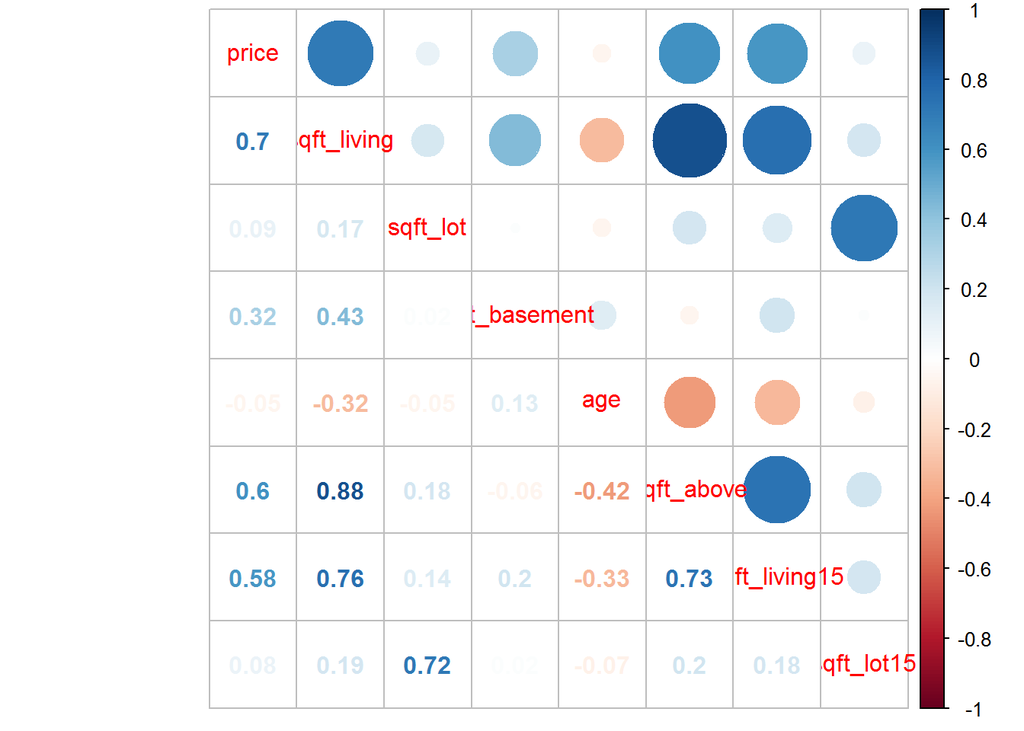

```r
M <- cor(house[,c("price", "sqft_living", "sqft_lot",
                  "sqft_basement", "age",
                  "sqft_above", "sqft_living15", "sqft_lot15")])
corrplot.mixed(M)
```

# Modelling

## Data Partitioning

```r
set.seed(1)
which_train <- createDataPartition(house$price,
                                   p = 0.8,
                                   list = FALSE)
```

## Split data into training and test set

```r
train <- house[which_train,]
test <- house[-which_train,]
```

### Data Visualization

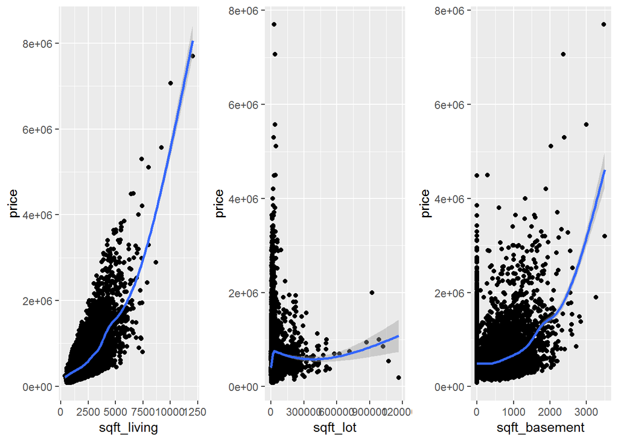

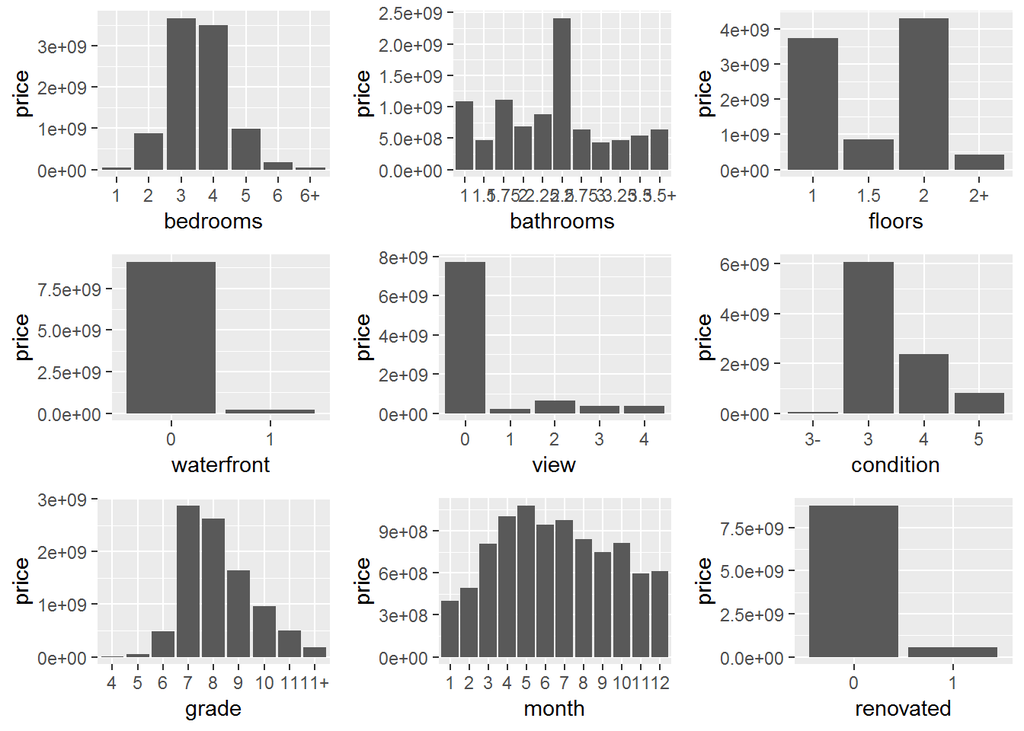

### Map of King County

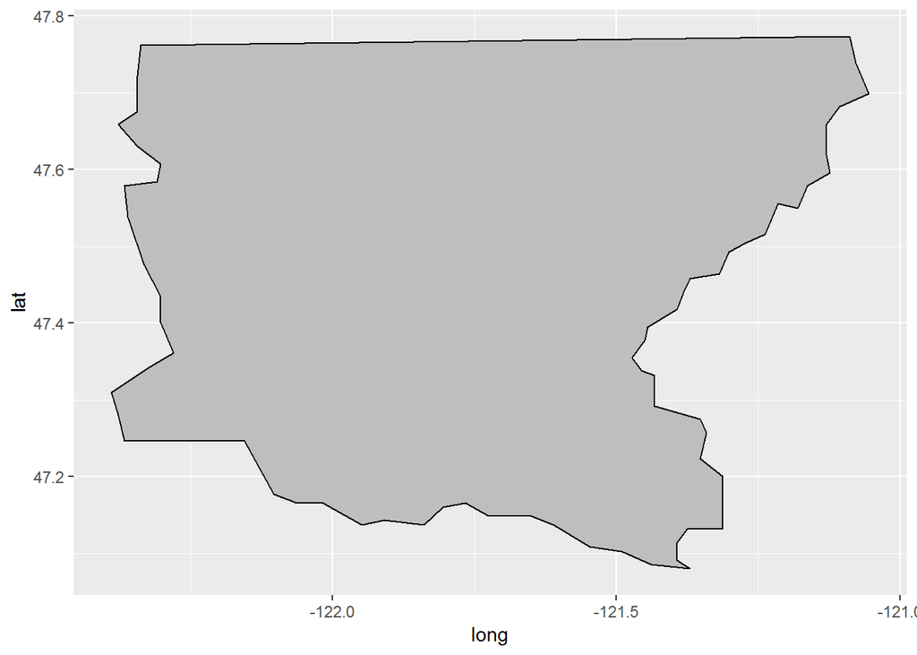

### Heat map of King County

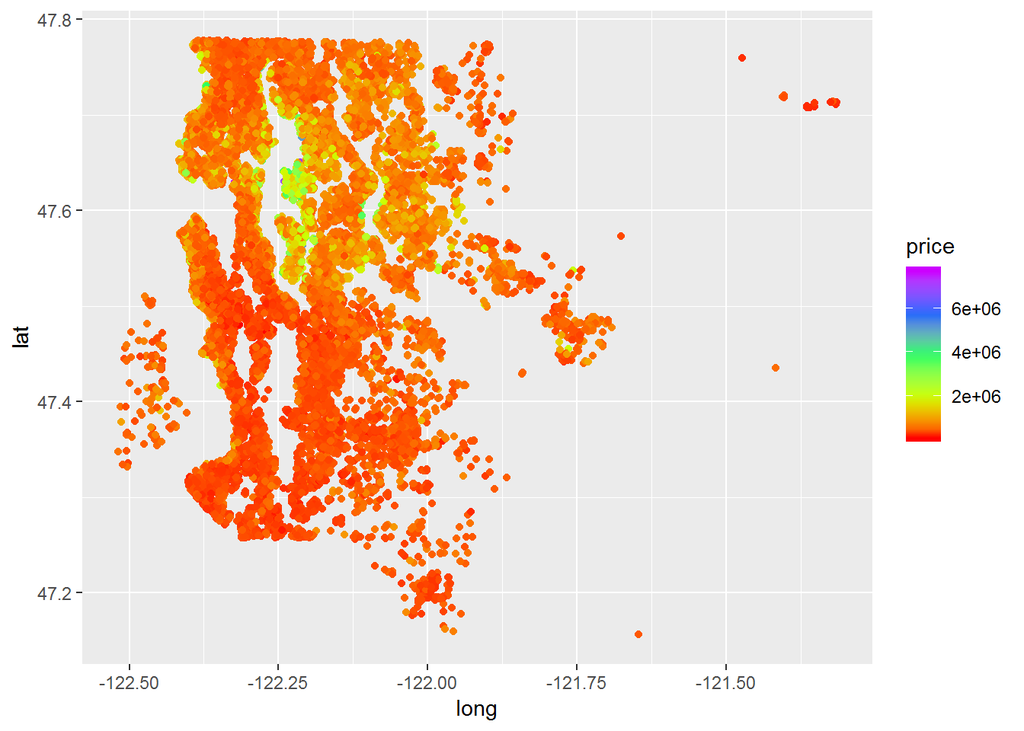

### More visualization

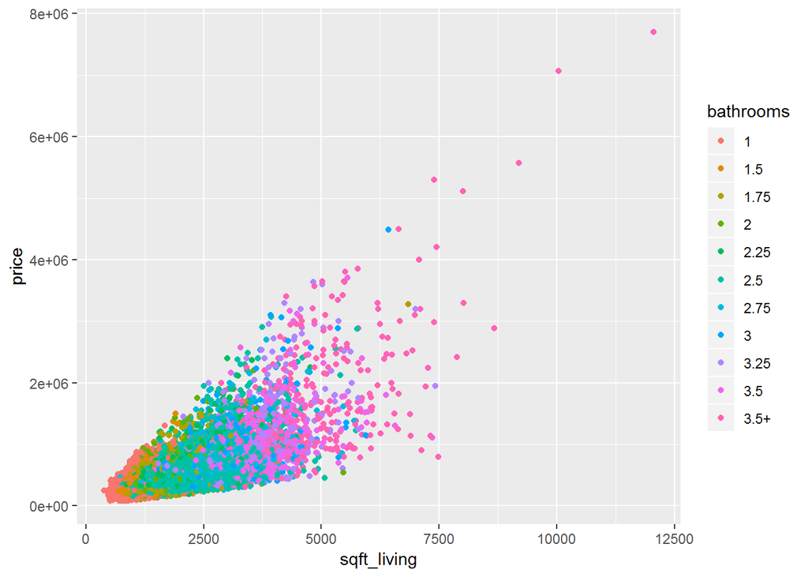

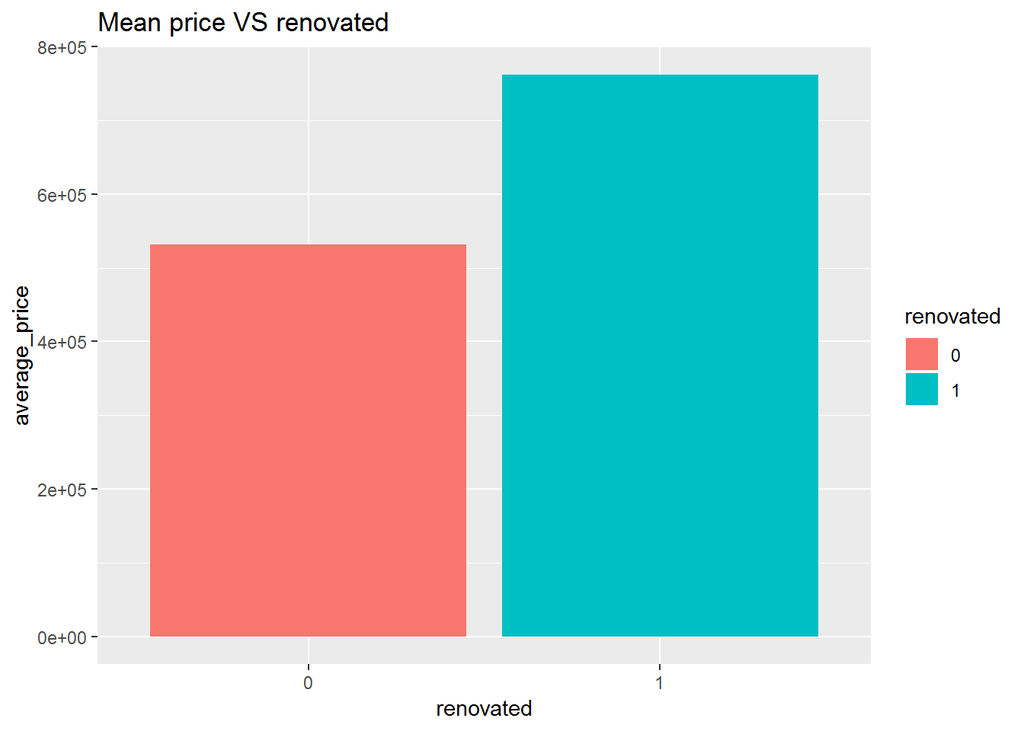

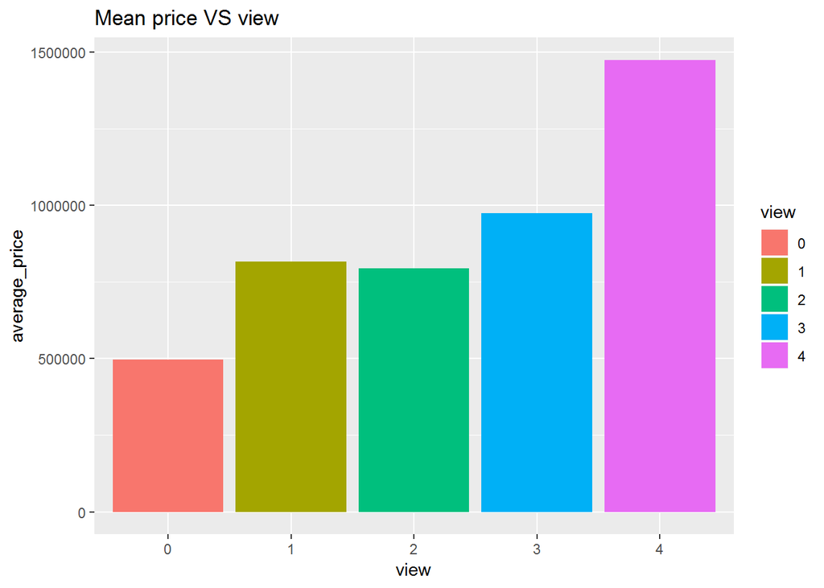

## Linear Regression

```r
set.seed(1)

formula <- price ~ bedrooms + bathrooms + sqft_living +
  sqft_lot + floors + waterfront + view + condition +
  grade + sqft_basement + zipcode +
  month + renovated

linear.train <-
  train(formula,
        data = train,
        method = "lm")
```

### Fitted values

```r
linear.train_fitted <- predict(linear.train, train)
```

### Predicted values

```r
linear.train_forecasts <- predict(linear.train, test)
```

### RMSE, R^2, MAE of test set

```r
error_measure.lm <- postResample(pred = linear.train_forecasts, obs = test$price)
```

### RMSE, R^2, MAE of train set

```r
postResample(pred = linear.train_fitted, obs = train$price)
```

```
##         RMSE     Rsquared          MAE
## 1.496397e+05 8.355731e-01 8.779856e+04
```

## SVM linear

### Setting train control

```r
ctrl_cv2 <- trainControl(method = "cv",
                         number = 2)
```

### Parameters of svmLinear

```r
modelLookup("svmLinear")
```

```
##       model parameter label forReg forClass probModel
## 1 svmLinear         C  Cost   TRUE     TRUE      TRUE
```

### Grid search

```r
parametersC <- data.frame(C = c(0.01, 0.1, 0.2, 0.5, 1, 5))
```

### Train data

```r
set.seed(1)
svm_Linear <- train(formula,
                    data = train,
                    method = "svmLinear",
                    tuneGrid = parametersC,
                    trControl = ctrl_cv2)
```

### Fitted values

```r
svm_linear.train_fitted <- predict(svm_Linear, train)
```

### Predicted values

```r
svm_linear.train_forecasts <- predict(svm_Linear, test)
```

### RMSE, R^2, MAE of test set

```r
error_measure.svm_linear <- postResample(pred = svm_linear.train_forecasts, obs = test$price)
```

#### RMSE, R^2, MAE of train set

```r
postResample(pred = svm_linear.train_fitted, obs = train$price)
```

```
##         RMSE     Rsquared          MAE
## 1.579167e+05 8.290153e-01 8.222068e+04
```

## SVM radial

### Parameters of svmRadial

```r
modelLookup("svmRadial")
```

```
##       model parameter label forReg forClass probModel
## 1 svmRadial     sigma Sigma   TRUE     TRUE      TRUE
## 2 svmRadial         C  Cost   TRUE     TRUE      TRUE
```

### Grid Search

```r
parametersC_sigma <-
  expand.grid(C = c(0.01, 0.05, 0.1, 0.5, 1, 5),
              sigma = c(0.05, 0.1, 0.2, 0.5, 1))
```

### Train data

```r
set.seed(1)
svm_radial <- train(formula,
                    data = train,
                    method = "svmRadial",
                    tuneGrid = parametersC_sigma,
                    trControl = ctrl_cv2)
```

### Fitted values

```r
svm_radial.train_fitted <- predict(svm_radial, train)
```

### Predicted values

```r
svm_radial.train_forecasts <- predict(svm_radial, test)
```

### RMSE, R^2, MAE of test set

```r
error_measure.svm_radial <- postResample(pred = svm_radial.train_forecasts, obs = test$price)
```

### RMSE, R^2, MAE of train set

```r
postResample(pred = svm_radial.train_fitted, obs = train$price)
```

```
##         RMSE     Rsquared          MAE
## 8.308042e+04 9.569912e-01 3.602115e+04
```

## Treebag

### Parameters of Treebag

```r
modelLookup("treebag")
```

```
##     model parameter     label forReg forClass probModel
## 1 treebag parameter parameter   TRUE     TRUE      TRUE
```

### Train data

```r
set.seed(1)
treebag.train <- train(formula,
                       data = train,
                       method = "treebag")
```

### Fitted values

```r
treebag.train_fitted <- predict(treebag.train, train)
```

### Predicted values

```r
treebag.train_forecasts <- predict(treebag.train, test)
```

### RMSE, R^2, MAE of test set

```r
error_measure.treebag <- postResample(pred = treebag.train_forecasts, obs = test$price)
```

### RMSE, R^2, MAE of train set

```r
postResample(pred = treebag.train_fitted, obs = train$price)
```

```
##         RMSE     Rsquared          MAE
## 2.263118e+05 6.291737e-01 1.559959e+05
```

## Bayesglm

```r
modelLookup("bayesglm")
```

```
##      model parameter     label forReg forClass probModel
## 1 bayesglm parameter parameter   TRUE     TRUE      TRUE
```

### Train data

```r
set.seed(1)
bayesglm.train <- train(formula,
                        data = train,
                        method = "bayesglm")
```

### Fitted values

```r
bayesglm.train_fitted <- predict(bayesglm.train, train)
```

### Predicted values

```r
bayesglm.train_forecasts <- predict(bayesglm.train, test)
```

### RMSE, R^2, MAE of test set

```r
error_measure.bayes_glm <-postResample(pred = bayesglm.train_forecasts, obs = test$price)
```

# RMSE, R^2, MAE of train set

```r
postResample(pred = bayesglm.train_fitted, obs = train$price)
```

```
##         RMSE     Rsquared          MAE
## 1.496397e+05 8.355730e-01 8.779858e+04
```

## CART

```r
modelLookup("rpart1SE")
```

```
##      model parameter     label forReg forClass probModel
## 1 rpart1SE parameter parameter   TRUE     TRUE      TRUE
```

### Train data

```r
set.seed(1)
rpart1SE.train <- train(formula,
                        data = train,
                        method = "rpart1SE")
```

### Fitted values

```r
rpart1SE.train_fitted <- predict(rpart1SE.train, train)
```

### Predicted values

```r
rpart1SE.train_forecasts <- predict(rpart1SE.train, test)
```

### RMSE, R^2, MAE of test set

```r
error_measure.cart <- postResample(pred = rpart1SE.train_forecasts, obs = test$price)
```

### RMSE, R^2, MAE of train set

```r
postResample(pred = rpart1SE.train_fitted, obs = train$price)
```

```
##         RMSE     Rsquared          MAE
## 2.434084e+05 5.649388e-01 1.644436e+05
```

# Conclusion

```r
error_measures <- data.frame(error_measure.lm, error_measure.svm_linear,
                             error_measure.svm_radial, error_measure.treebag,
                             error_measure.bayes_glm, error_measure.cart)
names(error_measures) <- c("lm","svm_linear","svm_radial","treebag","bayesglm","cart")
error_measures
```

```
##                    lm   svm_linear   svm_radial      treebag     bayesglm
## RMSE     1.488733e+05 1.513252e+05 2.634224e+05 2.246180e+05 1.488737e+05
## Rsquared 8.296537e-01 8.279697e-01 4.849898e-01 6.091055e-01 8.296501e-01
## MAE      8.981330e+04 8.291942e+04 1.342765e+05 1.568402e+05 8.981299e+04
##                  cart
## RMSE     2.430796e+05
## Rsquared 5.481711e-01
## MAE      1.650317e+05
```